# Geographic, Experiential, and Productivity Trends in Data Jobs

Author

Nakonde Ronah Precious

## About the datasets

This presentation examines trends in data jobs, particularly focusing on geographic and experiential factors and their impact on productivity. The study leverages data from Kaggle to address evolving job patterns in the data industry.

Two datasets were analyzed: one with data science job entries (9355 rows, 12 columns) and another with employee work patterns and productivity (1000 rows, 5 columns).

The first dataset provides insights into roles, salaries, locations, and employment types in data science.

The second dataset explores remote versus in-office employment, hours worked, productivity scores, and well-being scores.

The analysis aims to understand the impact of remote work on productivity and the broader implications for global job trends in tech.

My motivation for exploring data sets on job trends in data arises from the recent wave of layoffs in the tech industry during 2023-2024. This situation has sparked a debate among major tech CEOs, who argue that remote work diminishes productivity and that the same level of output can be achieved when employees are in the office. I aim to investigate whether this claim holds true by analyzing job trends in data science.

## Presentation Flow

[interactive chart not shown]

## Importing the Data

The two datasets were downloaded from the “data” folder that is present in my github repository.

## Descriptive Statistics

Descriptive Statistics for Data Jobs Dataset

| Statistic | Value |
| --- | --- |
| Min Salary (USD) | 15,000 |
| Max Salary (USD) | 450,000 |
| Mean Salary (USD) | 150,299 |
| Median Salary (USD) | 143,000 |
| SD Salary (USD) | 63,177 |
| Unique Work Years | 4 |
| Unique Company Locations | 70 |
| Unique Company Sizes | 3 |
| Experience Levels | 4 |
| Work Settings | 3 |

## Distribution of Jobs Among the different Data Categories

[output not shown]

## Data Jobs Trends From 2020 to 2023

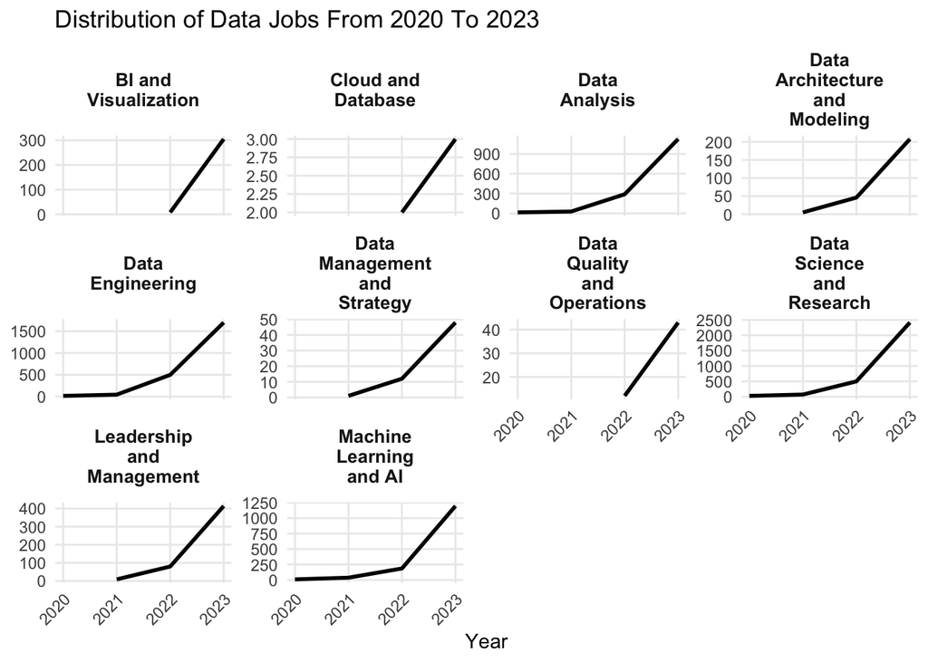

## Distribution of Work Settings Amongst Job Categories

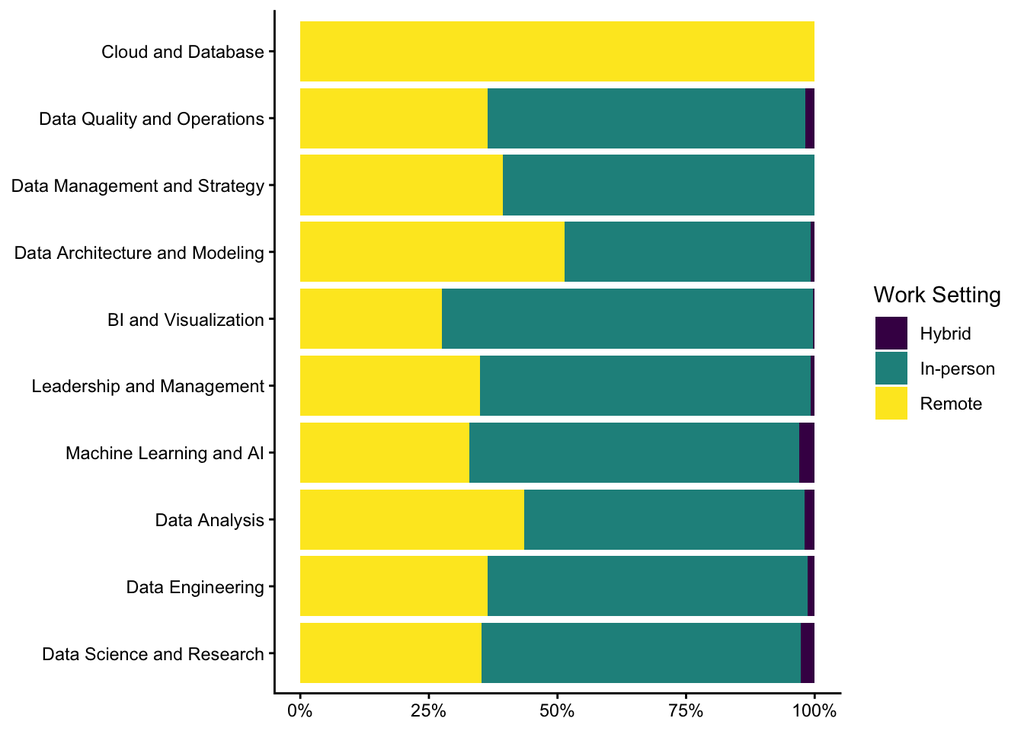

## Distribution of Jobs Among Company Sizes by Work Setting

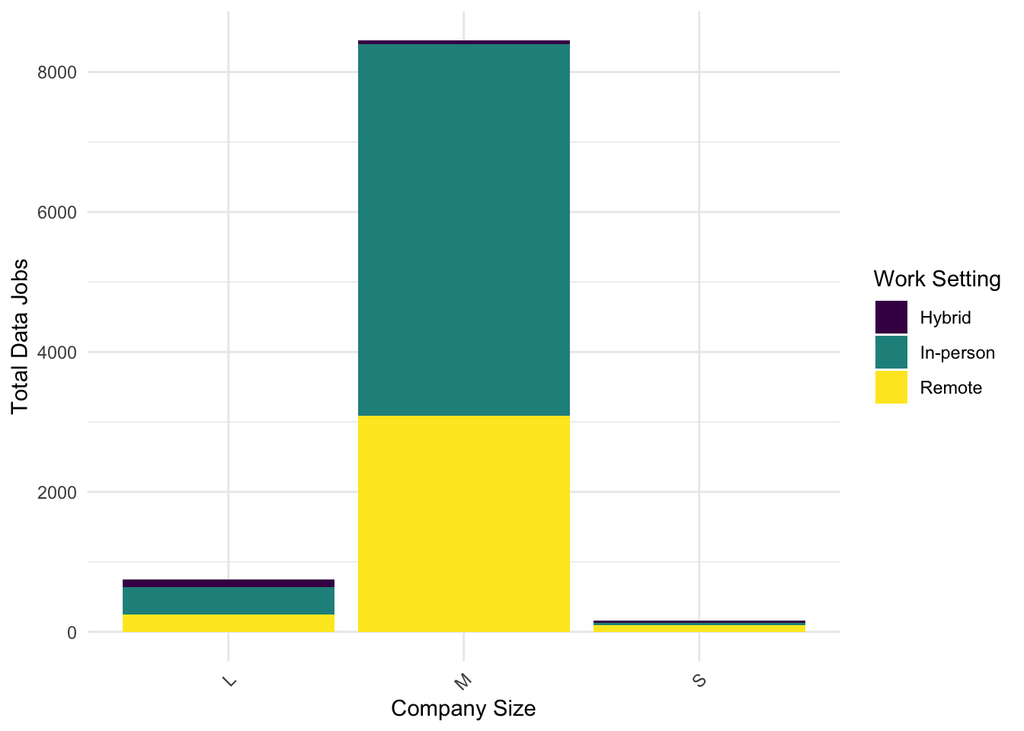

## Salary Distribution by Experience level and Work Setting

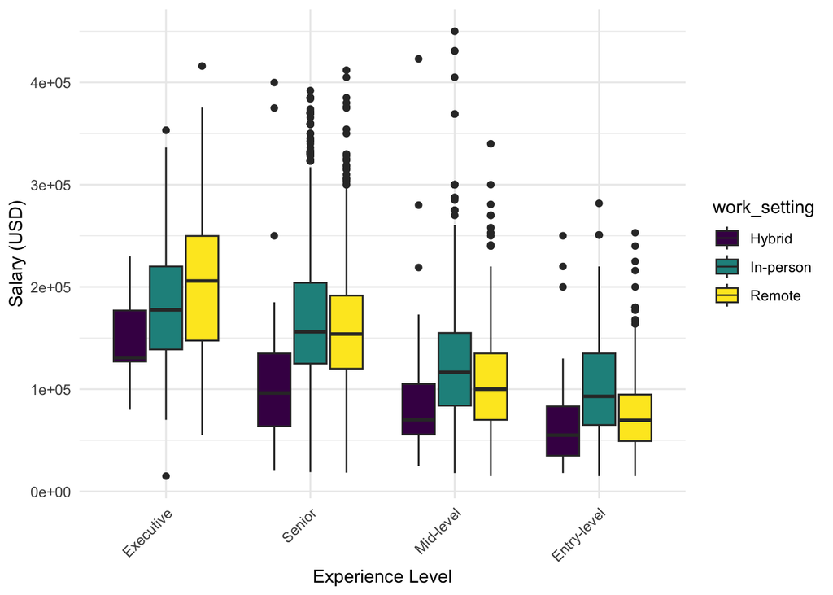

## Distribution of Jobs Amongst top 15 Company Location

Proportions of Jobs in Different Countries

| Country | Job Count Proportions Job Count | Job Count Proportions Proportion of Total Jobs |
| --- | --- | --- |
| United States | 8132 | 88.48% |
| United Kingdom | 449 | 4.89% |
| Canada | 226 | 2.46% |
| Spain | 113 | 1.23% |
| Germany | 72 | 0.78% |
| France | 50 | 0.54% |
| Australia | 24 | 0.26% |
| Portugal | 24 | 0.26% |
| Netherlands | 21 | 0.23% |
| Brazil | 17 | 0.18% |
| Colombia | 16 | 0.17% |
| Greece | 14 | 0.15% |
| Italy | 13 | 0.14% |
| Estonia | 10 | 0.11% |
| Mexico | 10 | 0.11% |

I chose to use company Location as opposed to the employee residence because for employees that work remotely, their residence is not representative of the company location or the country offering the job. Here I chose a cutoff point of 15 since majority of the jobs are concentrated in the top 5 company locations.

## Average Salary Heatmap by Company Location and Work Setting

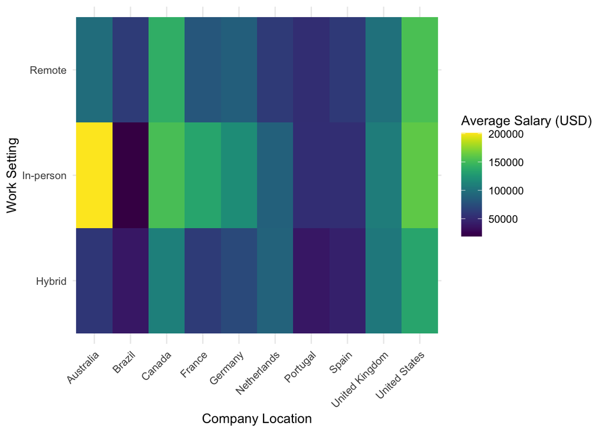

## Summary of Productivity Dataset

Summary of Productivity Dataset Metrics by Employment Type

| Employment_Type | Average Hours Worked | Average Productivity Score | Average Well-Being Score |
| --- | --- | --- | --- |
| In-Office | 44.43 | 63.77 | 58.67 |
| Remote | 34.82 | 73.63 | 69.49 |

## Relationship Between Hours Worked and Productivity

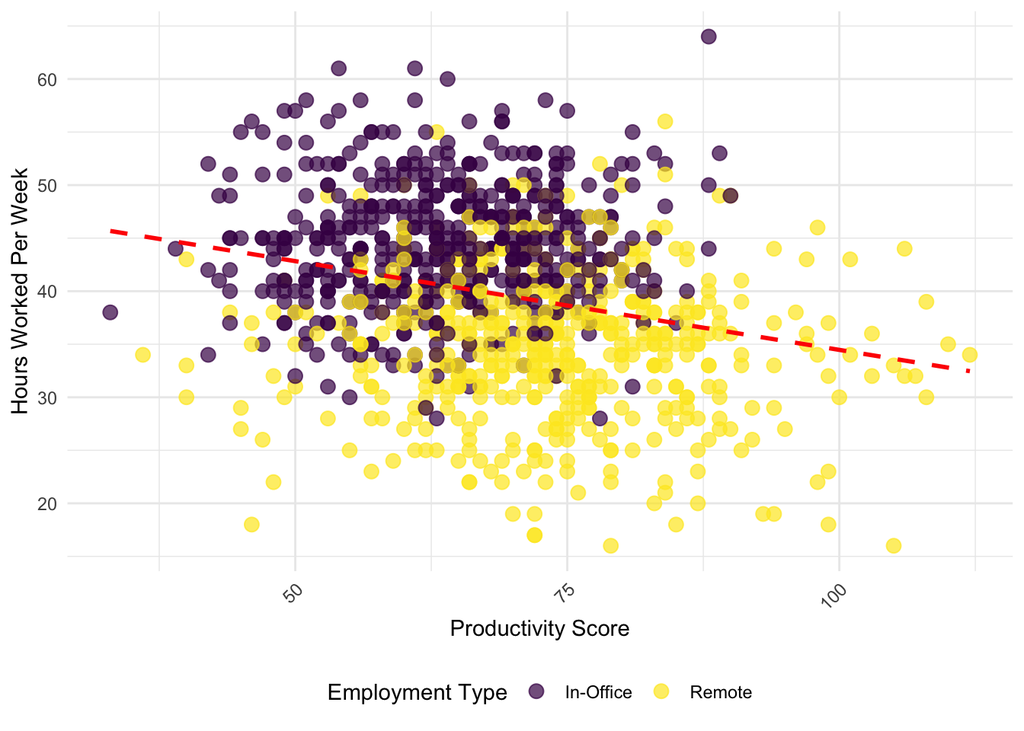

# Correlation

```
    Pearson's product-moment correlation

data:  productivity_data$Productivity_Score and productivity_data$Hours_Worked_Per_Week
t = -8.3154, df = 998, p-value = 2.971e-16
alternative hypothesis: true correlation is not equal to 0
95 percent confidence interval:
 -0.3116245 -0.1956432
sample estimates:
       cor
-0.2545489
```

We observe a weak negative correlation (r=−0.2545) between the productivity score and hours worked per week. This indicates that as hours worked increase, productivity scores tend to slightly decrease. The correlation is also statistically significant (p<0.001), meaning there is strong evidence in support of the negative relationship and it is unlikely to have occurred by chance.

## Well Being Score Distribution by Employment Type

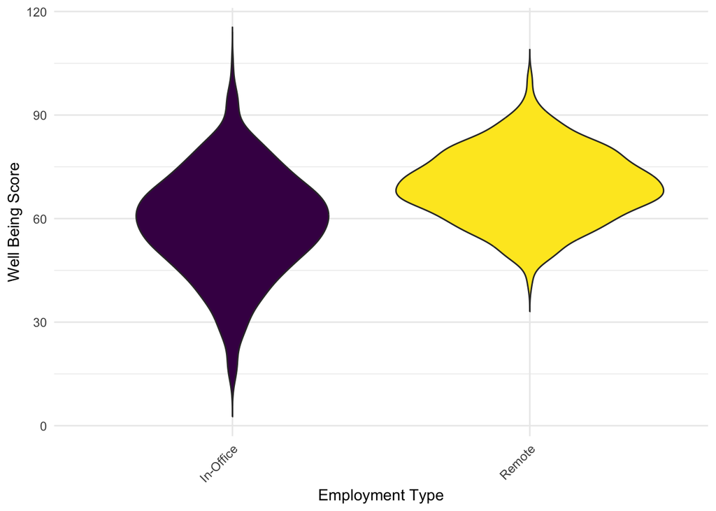

## Conclusions

Overview of Data Job Trends

There has been a significant growth in data roles from 2020 to 2023. Diverse job categories with varying opportunities have come up. It is mostly small companies that provide the largest proportion of remote jobs as compared to large companies.

Experiential Factors

There are salary variations based on experience levels, with executives that work remotely earning the most while entry level workers that do hybrid earning the least.

Geographic Insights

There is a predominance of data jobs in the United States, followed by the UK and Canada. The highest paying jobs in the top 10 countries with data jobs are in-person(in-office).

Impact of Work Settings on Productivity

The data and analysis show that longer hours does not necessarily equate to higher productivity, challenging traditional office work assumptions that the big tech executives are pushing to bring back. Even the well-being score of those working remotely is higher than there counterparts that work fully in office.

## Closing Remark

In my opinion, big tech CEO’s that claim that the reason for the major layoffs in the past two years is attributed to lower productivity due to remote and hybrid work settings is not entirely true. As we can see from the data, they also spend more on wages and compensation to workers that work from office and therefore their cost cutting agenda is also not justified in this case.

So what is the real reason as to why big tech companies are forcing people back into the office fulltime and also carrying out massive layoffs?